# Cape Vulture collision risk model tests

FCervantes

8/27/2020

## Introduction

In this document we explore three different approaches to predicting use of space by Cape Vultures. We base predictions in resource selection models. These models analyse the preferential use of resources, by comparing those found at the used (observed) locations to those available for the bird. A key decision when modelling resource selection is the subjective choice of the area available for the bird and this question gives rise to the three different modelling approaches compared here:

**1. Availability is defined within an area around the colony**. We define colony as the point with highest density of points (we may use known colony locations when we have them). The main advantage of this option is that it availability is not constrained by the observed locations and therefore it can be set prior to seeing any data. However, we need to set a hard distance threshold to define an area around the colony, for which we probably want to look at the data. Then, there might be uncontrolled variables that hold the birds within their home range and therefore, we might be stablishing an unrealistic available range. In addition, young birds don’t stay close to the colony and therefore taking the colony as a reference might not be a good option. If we were to set a threshold distance for young birds, because they can move thousands of kilometers from the colony, we would have to define an enormous area around the colony.

**2. Availability is defined within the area enclosing the observed activity of the bird**. This could be considered as selection within home range. Although this selection is at a finer scale, considering avaibility only around observed locations eases the problem of considering locations that would have never been visited by the birds, as “available”. There is still some degree of subyectivity in the choice of the boundaries of the available area but, in practice, different choices would probably lead to similar results.

**3. Availability is defined sequentially “step-by-step”**. We assume that given the sampling scheme, bird movement constrains availability to areas close to the current location. This is not to say that the birds are oblivious to what happens beyond a certain range, but that they select those steps that take him to the desired location. For example, birds might choose to select those locations that take them close to the colony (pixels characterized by distance-to-colony variable), although the colony might be beyond their reach. However, they won’t be able to select an orographic slope if there are none within its reach (no pixels classified as steep within reach). With this option we let the data dictate the availability range by looking at movement characteristics, therefore eliminating the subyectivity of this choice.

The objective is to understand which of these options performs better at predicting resource selection. To do this, we fit these models to some data and predict resource selection at locations different from the one used to fit the models. We will use data from six different birds of different age, living in different areas. We analyse each bird separately to guarantee that used locations are matched only to those locations that were ever available to the birds. Note that some of these birds live thousands of kilometers away. In *step selection analysis* (model option 3) this shouldn’t be an important problem, but it would be for options 1 and 2, which I will refer to as *resource selection analysis*. Then, we use the coefficients of one bird to predict resource selection for this bird and also the other birds.

## Vulture data

As mentioned before, we use one year of tracking data of each of six birds of different ages.

- Here is some basic tracking information: number of locations, average sampling frequency and standard deviation of sampling frequency,

```
## # A tibble: 6 x 5
## # Groups:   bird_id [6]
##   bird_id age    nloc avg_dt sd_dt
##   <chr>   <chr> <int>  <dbl> <dbl>
## 1 ma14    ad    37038  0.237  1.25
## 2 ma15    juv   28218  0.311  1.75
## 3 na03    ad     3317  2.64   4.30
## 4 na06    juv    5322  1.65   2.32
## 5 wt07    ad      880 10.1   20.8
## 6 wt18    juv    1040  8.05   5.73
```

- A tracking timeline of the birds used for the tests:

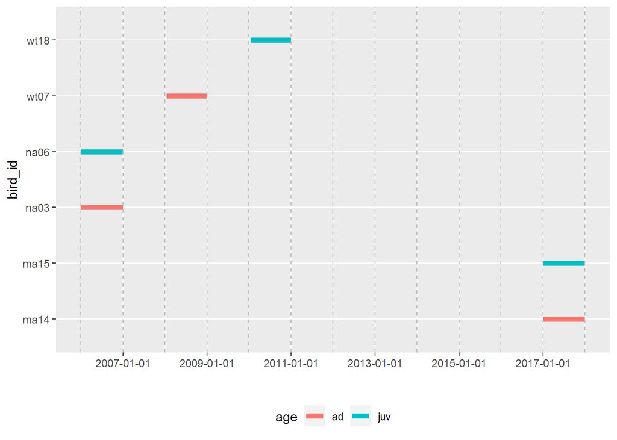

Tracking timeline

- And the general distribution of locations:

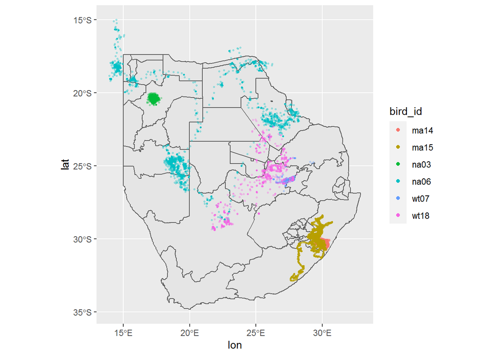

Distribution of tracking locations

## Covariates

In all models we use four explanatory variables for the test:

- distance from colony,
- elevation,
- slope,
- vector ruggedness index (VRM, a measure of terrain roughness).

## 1. Resource selection from colony buffer

Here we fit a model considering availability to be in a buffer around the colony (option 1 in the introduction). We only use adult birds since juveniles disperse too far.

First, we show the plots of used vs. available points. We took the distance that leaves 99% of the points inside, just to avoid stray locations to influence results too much. However, taking 100% in these particular cases would not be a problem, and it would not change the results considerably.

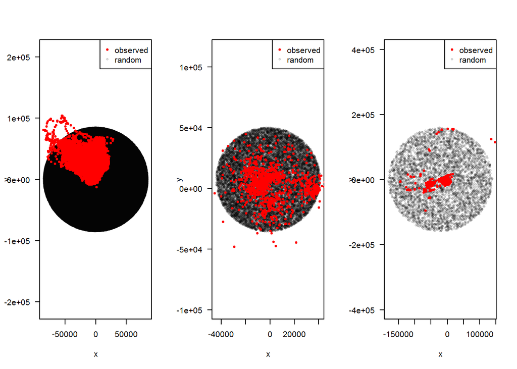

Observed vs. available

The fitted model is as follows:

$$\log\left[ \frac { P( \operatorname{case\_} = \operatorname{FALSE} ) }{ 1 - P( \operatorname{case\_} = \operatorname{FALSE} ) } \right] = \alpha + \beta_{1}(\operatorname{srtm}) + \beta_{2}(\operatorname{slope}) + \beta_{3}(\operatorname{vrm3}) + \beta_{4}(\operatorname{dist}) + \epsilon$$

The standardized coefficients for these adult birds are as follows:

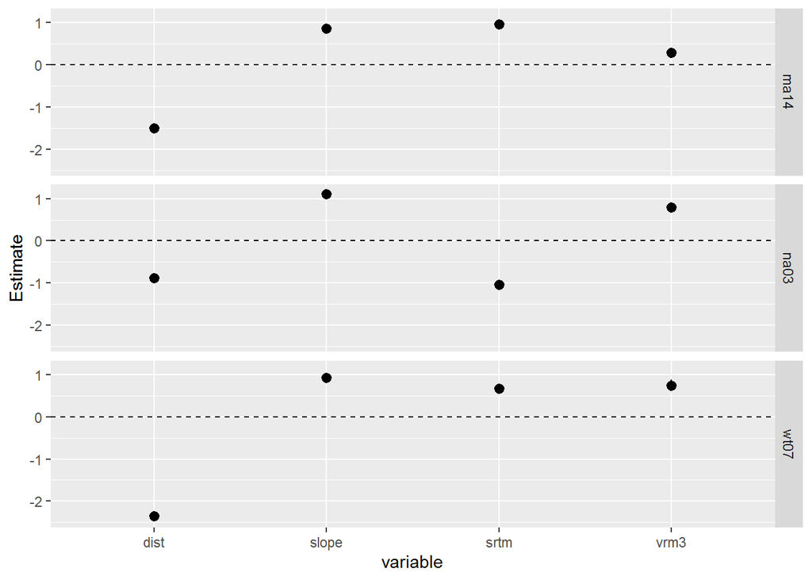

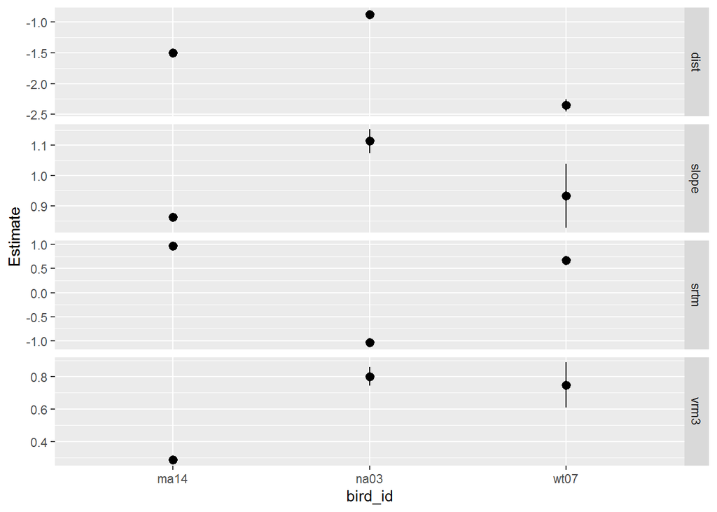

## 2. Resource selection from occurrence

Here we fit a model considering availability to be in the surroundings of observed locations (option 2 in the introduction).

First, we show the plots of used vs. available points. We took a buffer of 5km around the minimum complex polygon enclosing the observed locations.

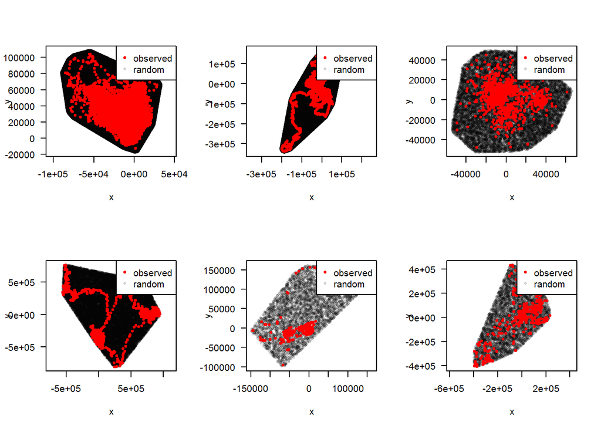

Observed vs. available

The fitted model is as follows:

$$\log\left[ \frac { P( \operatorname{case\_} = \operatorname{FALSE} ) }{ 1 - P( \operatorname{case\_} = \operatorname{FALSE} ) } \right] = \alpha + \beta_{1}(\operatorname{srtm}) + \beta_{2}(\operatorname{slope}) + \beta_{3}(\operatorname{vrm3}) + \beta_{4}(\operatorname{dist}) + \epsilon$$

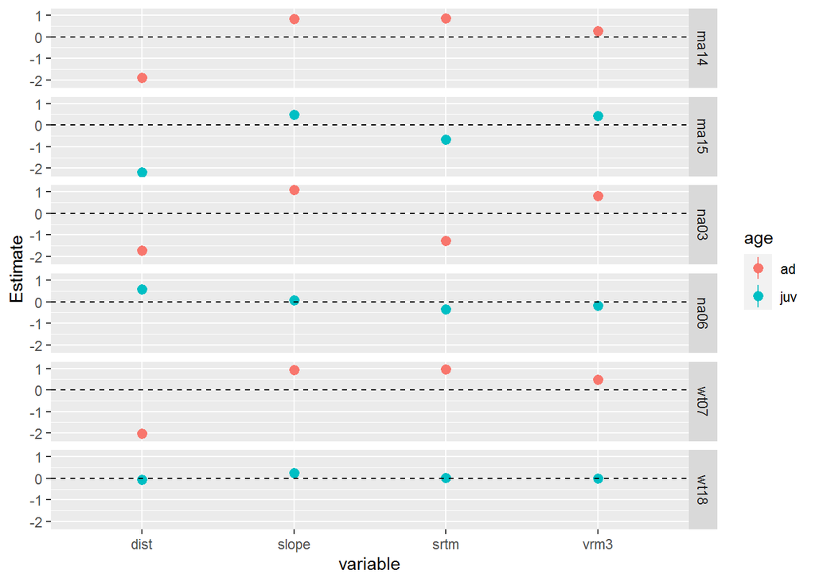

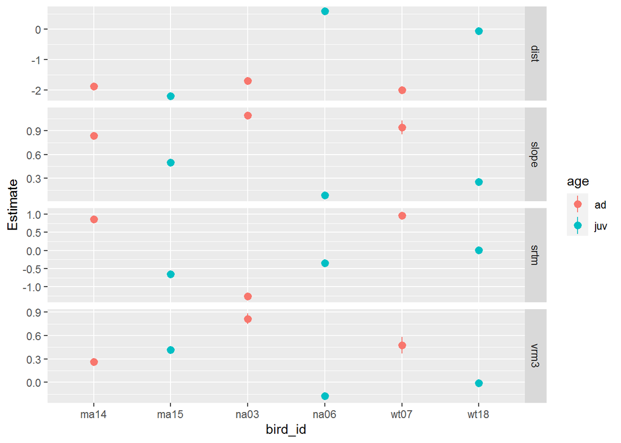

## 3. Step selection

Here we fit a step-selection model considering availability is influenced by the movement characteristics of the bird. Two of the birds didn’t have a fine enough resolution to fit a movement model. This problem could be circumvented by using step lengths only but I haven’t prepared that yet.

First, we show the plots of used vs. available points. Random steps are simulated from fitted step lengths and turning angles distributions fitted to the observed data.

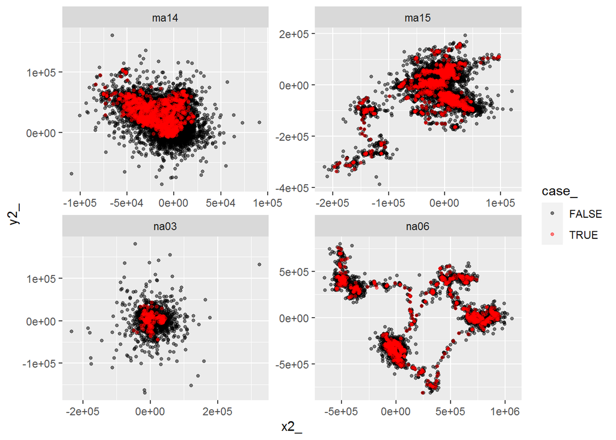

Observed vs. available

The fitted model is as follows:

Sorry it seems like fancy formula printing package doesn’t support this model object yet :(

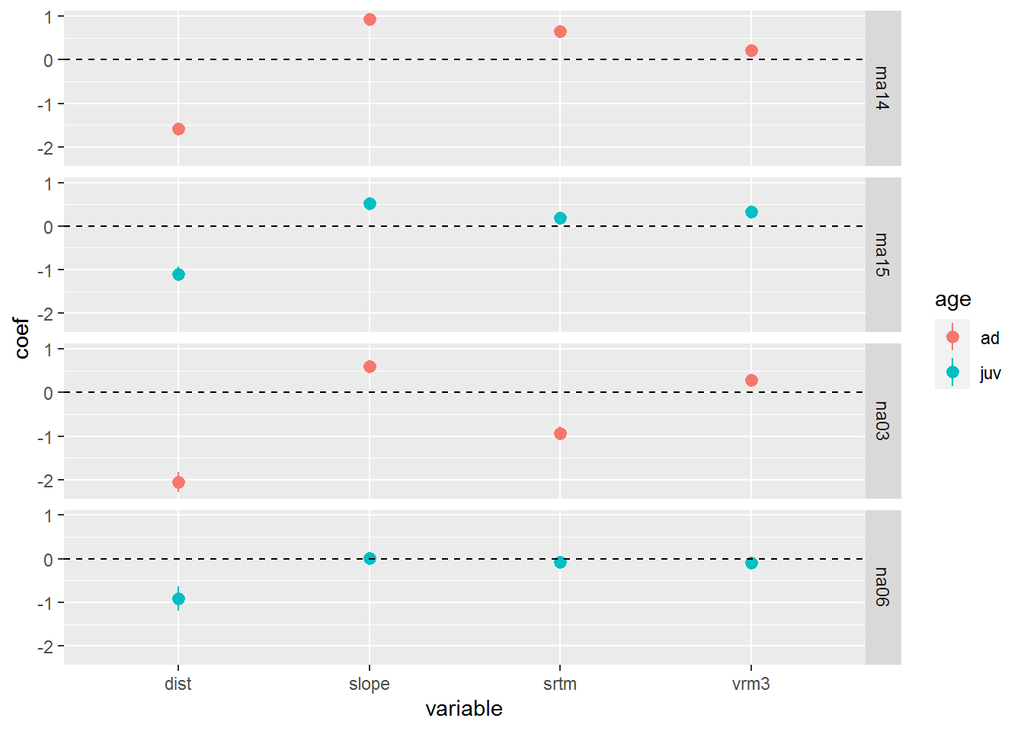

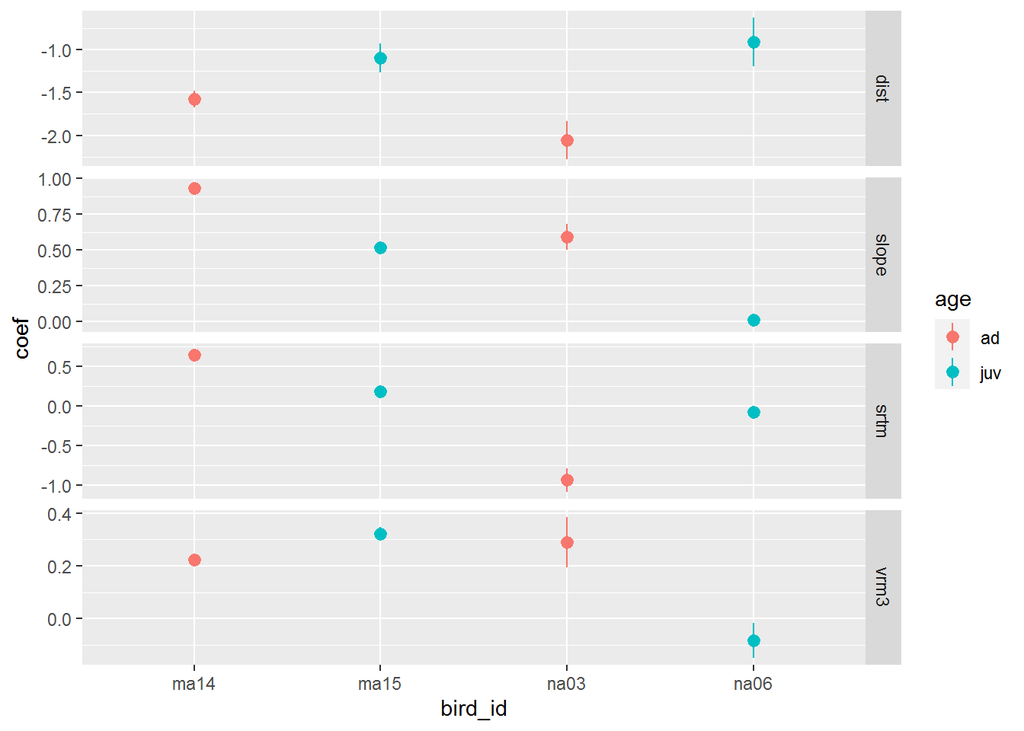

## 4. Model comparison

To compare models we take a 200 km radius buffer around each bird’s colony. Then, with the different model outputs we generate predictions and contrast these with the observed locations. The different steps are the following:

1. Choose a target bird to make predictions about.

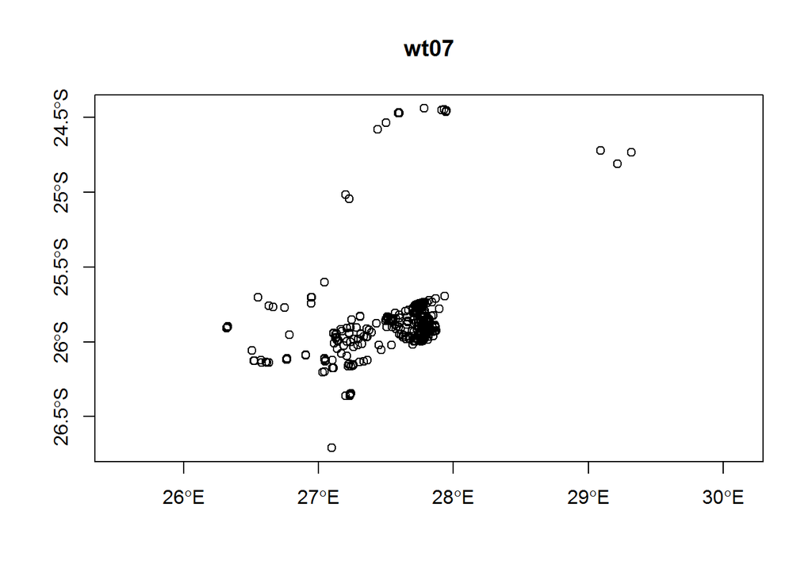

2. Find its colony and define a 200 km buffer around.
3. Set raster covariates for the area

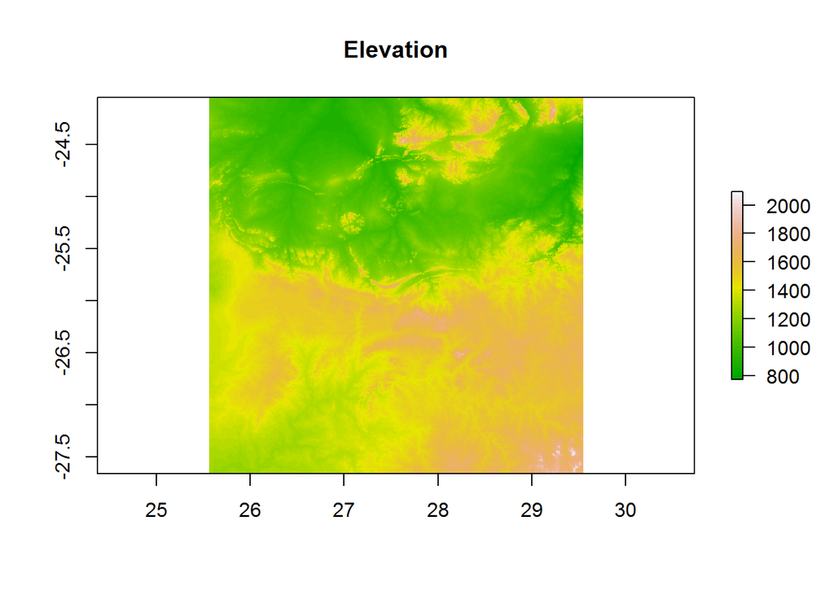

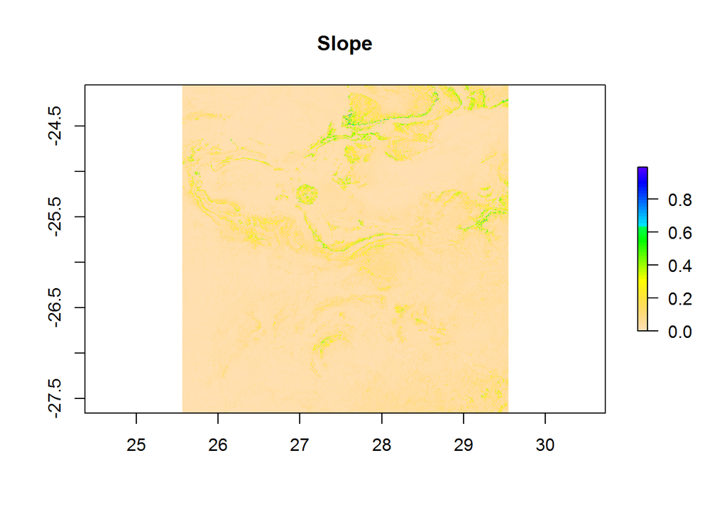

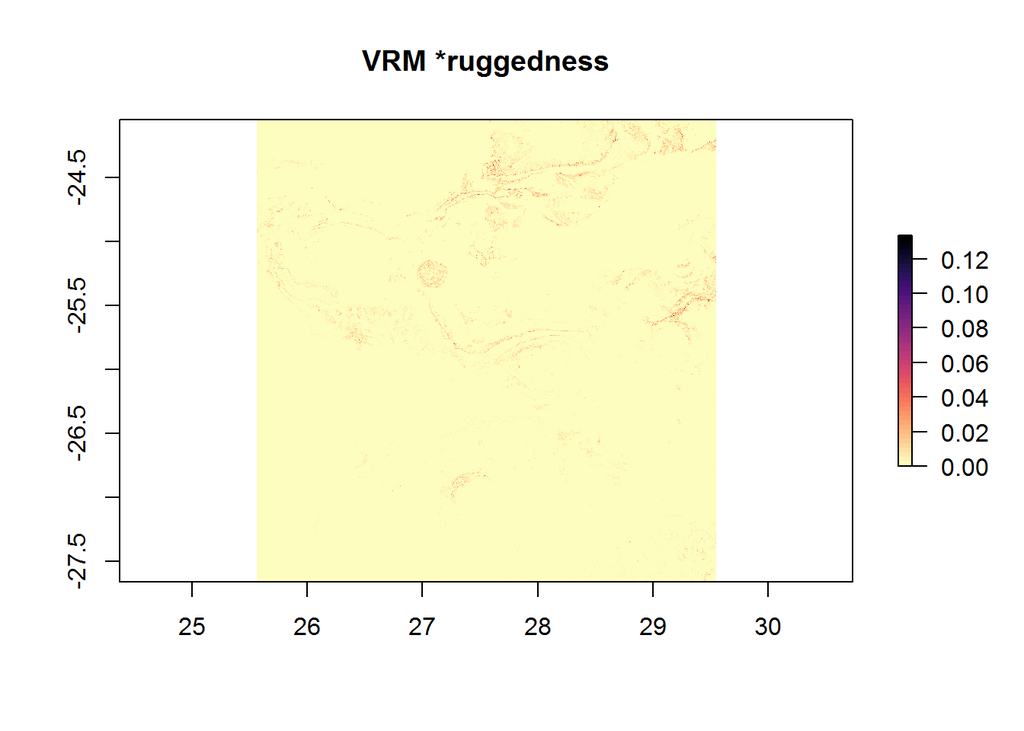

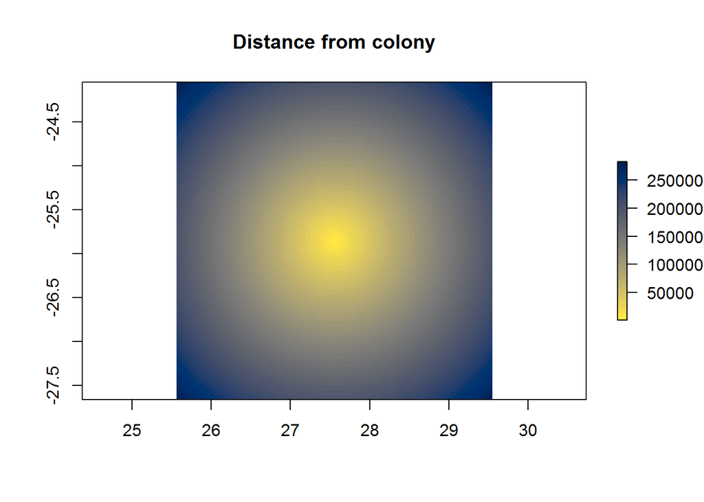

```
4. Choose a model and a bird to predict from (e.g. RSF_home_range fitted to "ma14")

5. Predict over the range of the covariates
```

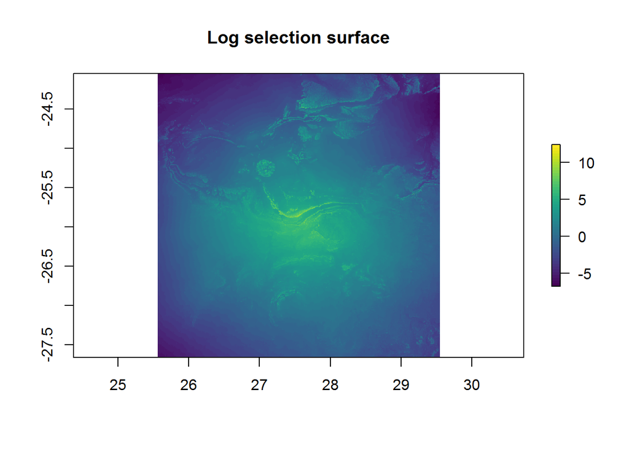

```
6. Exponentiate and normalize predictions to calculate selection values

7. Extract selection values at the observed locations

8. Take log of selection at, and sum across, all observed locations.

9. Repeat this process for all models and birds.
```

In the following plot we summarize the results of the cross-validation tests:

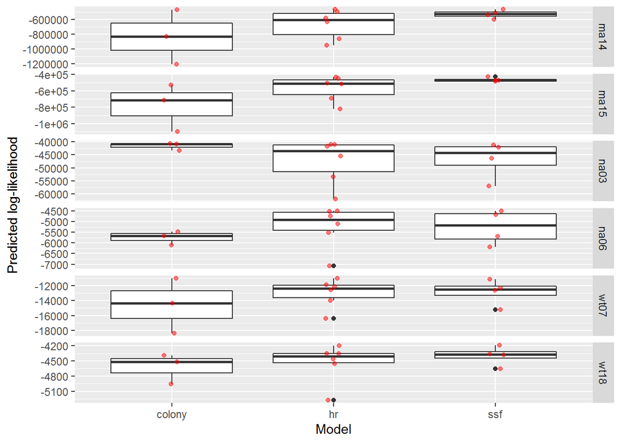